# Lab-4

10.7.21

## 1. Comparing two classification methods

In this question we will compare two different methods from different classifier families, to classify hand written numbers 3 and 8.

We choose a *two-class* method to build a tree and a multinomial regression.

```
##
## Classification tree:
## rpart(formula = y ~ ., data = my_train, method = "class", cp = 1e-06)
##
## Variables actually used in tree construction:
##  [1] X121 X131 X182 X263 X264 X303 X320 X324 X354 X412 X431 X439 X456 X461 X468
## [16] X486 X488 X489 X490 X491 X496 X513 X514 X516 X518 X537 X541 X543 X545 X573
## [31] X626 X682
##
## Root node error: 1922/4000 = 0.4805
##
## n= 4000
##
##            CP nsplit rel error  xerror      xstd
## 1  0.71904266      0  1.000000 1.00000 0.0164405
## 2  0.05775234      1  0.280957 0.28096 0.0112448
## 3  0.02809573      2  0.223205 0.22685 0.0102548
## 4  0.01821020      4  0.167014 0.17430 0.0091154
## 5  0.01092612      5  0.148803 0.15973 0.0087594
## 6  0.00702393      6  0.137877 0.15349 0.0086005
## 7  0.00554977      8  0.123829 0.14464 0.0083681
## 8  0.00546306     11  0.107180 0.14256 0.0083121
## 9  0.00520291     13  0.096254 0.14256 0.0083121
## 10 0.00468262     14  0.091051 0.13580 0.0081267
## 11 0.00364204     16  0.081686 0.12279 0.0077535
## 12 0.00286160     17  0.078044 0.11186 0.0074211
## 13 0.00260146     19  0.072320 0.11238 0.0074374
## 14 0.00234131     22  0.064516 0.11290 0.0074536
## 15 0.00156087     24  0.059834 0.10718 0.0072728
## 16 0.00052029     26  0.056712 0.10354 0.0071547
## 17 0.00000100     33  0.053070 0.10770 0.0072894
```

## 2. Confusion Matrix

```r
confusion_matrix <- function(t, l){
  m <- matrix(0,nrow = 2,ncol = 4)
  rownames(m) <- c("False(8)", "True(3)")
  colnames(m) <- c("No(8)", "Yes(3)","No(8)", "Yes(3)")

  m[1,1] <- t[2,2]
  m[1,2] <- t[2,1]
  m[1,3] <- t[2,2] / l
  m[1,4] <- t[2,1] / l

  m[2,1] <- t[1,2]
  m[2,2] <- t[1,1]
  m[2,3] <- t[1,2] / l
  m[2,4] <- t[1,1] / l
  accuracy_Test <- sum(diag(t)) / sum(t)
  return(list(matrix = m,accuracy = accuracy_Test))
}
```

Next, we ran our function on each model (test and train) to check if we have an over-fitting.

Confusion Matrix - Tree train

|  | No(8) | Yes(3) | No(8) | Yes(3) |
| --- | --- | --- | --- | --- |
| False(8) | 1869 | 53 | 0.46725 | 0.01325 |
| True(3) | 71 | 2007 | 0.01775 | 0.50175 |

Note: The Accuracy is: 0.969

Confusion Matrix - Tree Test

|  | No(8) | Yes(3) | No(8) | Yes(3) |
| --- | --- | --- | --- | --- |
| False(8) | 936 | 38 | 0.4717742 | 0.0191532 |
| True(3) | 40 | 970 | 0.0201613 | 0.4889113 |

Note: The Accuracy is: 0.961

Confusion Matrix - Multinomial Train

|  | No(8) | Yes(3) | No(8) | Yes(3) |
| --- | --- | --- | --- | --- |
| False(8) | 1850 | 72 | 0.46250 | 0.01800 |
| True(3) | 73 | 2005 | 0.01825 | 0.50125 |

Note: The Accuracy is: 0.964

Confusion Matrix - Multinomial Test

|  | No(8) | Yes(3) | No(8) | Yes(3) |
| --- | --- | --- | --- | --- |
| False(8) | 898 | 76 | 0.4526210 | 0.0383065 |
| True(3) | 67 | 943 | 0.0337702 | 0.4753024 |

Note: The Accuracy is: 0.928

We can see that there is 96% accuracy in the first 3 and 92.7% in the last 1. This shows that the models are very accurate and we probably don’t have overfitting so we get a very good accuracy all along - all false values are close to zero and true values are close to there real value.

## 3. ROC

In this question we wrote a function that calculates and plots the ROC curve and the AUC value, AUC is the probability that we get a true positive greater than a true negative.

```r
roc_curve <- function(train,test,probability,breaks = 1000, model_name) {
  roc <- data.frame(x = 0,y = 0,ct = 0)

  for (cutoff in seq(0,1, by = 1/breaks)) {
    index <- which(probability  >= cutoff)
    x = ifelse(length(index) >= 1, length(which(my_test$y[index] == 8)) / ( length(which(my_test$y == 8))), 0)
    y = ifelse(length(index) >= 1, length(which(my_test$y[index] == 3)) / ( length(which(my_test$y == 3))), 0)
    temp = c(x,y,cutoff)
    roc <- rbind(temp,roc)
  }

  roc <- roc[-1,]
  auc = mean(roc$y>roc$x)
  p = ggplot(data=roc, aes(x=x, y=y)) + geom_line(colour = "steelblue", size=1)+ geom_abline(intercept = 0, slope = 1, colour = "steelblue", size=1)+
              ylim(0,1)+ xlim(0,1)+
              ggtitle(paste("ROC Curve",":",model_name), subtitle = paste('AUS', ': ', as.character(round(auc,5))))+
              xlab("False positive rate")+ ylab("True positive rate")+theme_bw()

    return(p)

}
```

Now, we use this function to draw the ROCs for both classifers.

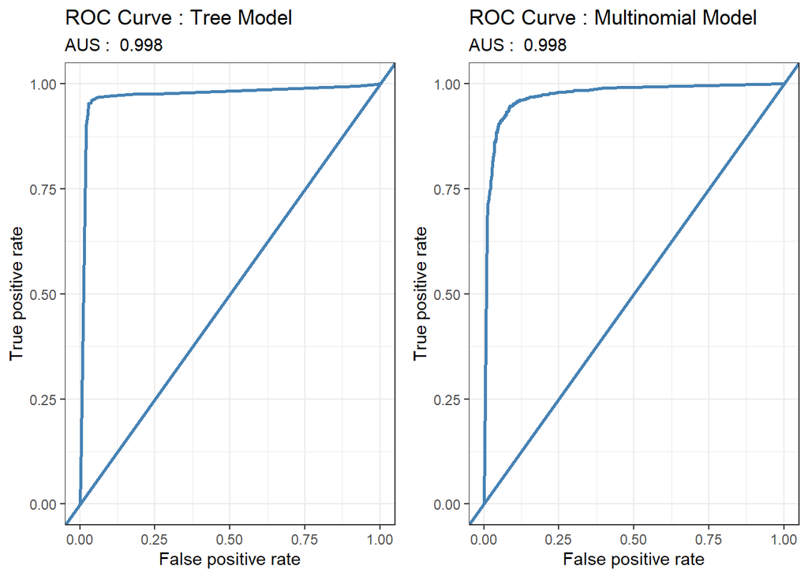

As we can see the in the plots, the ROC curves show satisfying results -the AUC values for both models are close to 1 (approximately 0.998).

Because of the similarities between the models, it can be assumed that both are very good, and any model chosen from both will be a good predictive model.

## 4. Examples that were classified incorrectly.

In this question we displayed four examples that were classified incorrectly, and tried to interpret what made these examples hard for the classifier.

First, we looked at all the examples that were classified incorrectly and chose four of them.

The first one we chose is:

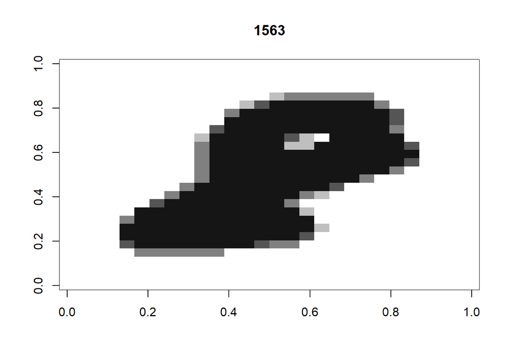

We can see that the image looks like a blob of black with a small circle inside therefore it can be interpreted as a 3 or an 8. The real number is 8, the shape of the black blob does indeed look like an 8 also since there is only 1 circle of white the model could assume its a 3.

The second one is:

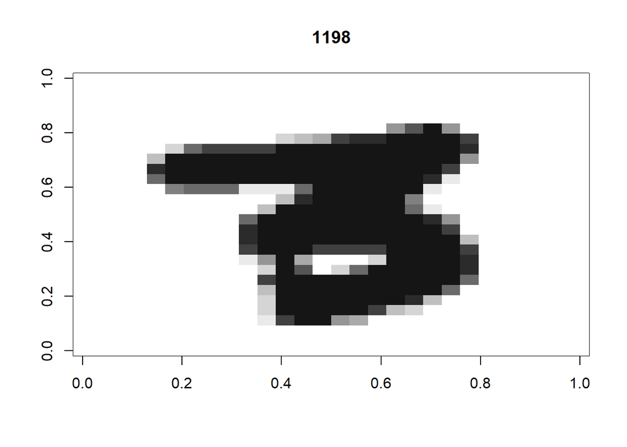

the real number is 3 and the model assumed it’s an 8. the model was probably wrong because the bottom circle is closed like in an 8 therefore it was mistaken.

The next one is:

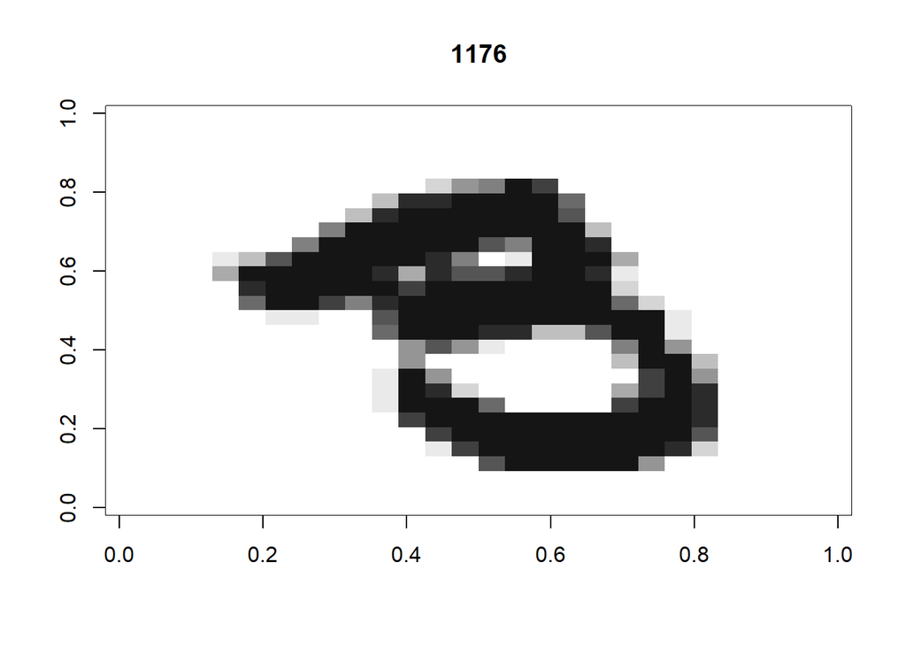

In this image it is very hard to know what number is the right number even for a human’s eye since on one hand there are 2 circles like an 8 and on the other hand the two circles look a bit open like a 3 therefore it makes since that the model was wrong. after checking the real data, we can see that the number is a 3.

The last one is:

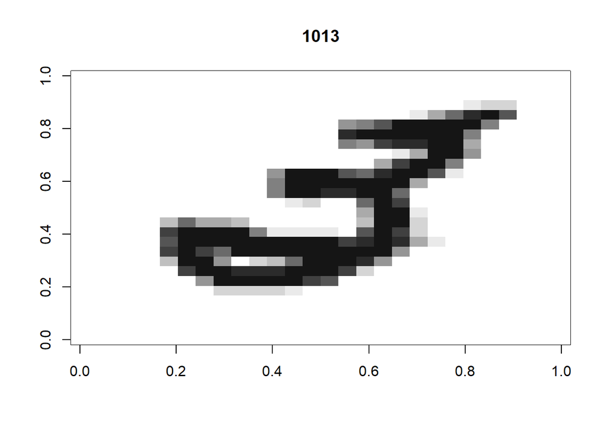

The real number here is a 3 also in the image we can see that there is one closed circle and two opened circles and if you look at the bottom of the image it looks like an 8 and if you look at the top it looks like a 3 therefore it makes since the model was wrong here

## 5. Classifiers on specific image

In the training dataset, we trained the model on the Pixel values that are between 0 to 255, when 0 means white and 255 means black. What matters to a neural net are the pixel values 0 (background) and 255 (foreground), though you can assign different colors to these pixel values when plotting the images. A neural net trained on images with 0 as background and 255 as foreground will not be able to recognize images with inverted colors. we would need to train a neural net on both types of images if we want it to work on both.